# Statistical Learning Project - Great Learning ( Project-1)

## (1) Import Python Libraries and apply global configurations

```python
# import necessary Python libraries for data analysis
import pandas as pd
import numpy as np
import matplotlib.pyplot as plt
import seaborn as sns
import scipy.stats as stats
from statsmodels.stats.weightstats import ztest
import statsmodels.api as sm
from statsmodels.formula.api import ols

# enable matplotlib to be used inline with Jupyter Notebook and additional enablement.
%matplotlib inline
sns.set()
sns.set(style="whitegrid", palette="pastel")
# sns.set_style("whitegrid",palette="pastel")

plt.rcParams["figure.figsize"] = (20,8)
```

## (2) Read the CSV file into a data frame

```python
# Read the insurance.csv into a data frame and display the top 5 rows of the data frame along with the header
df = pd.read_csv("insurance.csv")
df.head(10)
```

|  | age | sex | bmi | children | smoker | region | charges |
| --- | --- | --- | --- | --- | --- | --- | --- |
| 0 | 19 | female | 27.900 | 0 | yes | southwest | 16884.92400 |
| 1 | 18 | male | 33.770 | 1 | no | southeast | 1725.55230 |
| 2 | 28 | male | 33.000 | 3 | no | southeast | 4449.46200 |
| 3 | 33 | male | 22.705 | 0 | no | northwest | 21984.47061 |
| 4 | 32 | male | 28.880 | 0 | no | northwest | 3866.85520 |
| 5 | 31 | female | 25.740 | 0 | no | southeast | 3756.62160 |
| 6 | 46 | female | 33.440 | 1 | no | southeast | 8240.58960 |
| 7 | 37 | female | 27.740 | 3 | no | northwest | 7281.50560 |
| 8 | 37 | male | 29.830 | 2 | no | northeast | 6406.41070 |
| 9 | 60 | female | 25.840 | 0 | no | northwest | 28923.13692 |

## (3) Basic Exploratory Data Analysis

```python
# Display the shape of the data frame
df.shape
```

```
(1338, 7)
```

#### The data frame has 1338 Rows and 7 Columns

```python
# Display each attribute/column and it's data type
df.info()
```

```
<class 'pandas.core.frame.DataFrame'>
RangeIndex: 1338 entries, 0 to 1337
Data columns (total 7 columns):
 #   Column    Non-Null Count  Dtype
---  ------    --------------  -----
 0   age       1338 non-null   int64
 1   sex       1338 non-null   object
 2   bmi       1338 non-null   float64
 3   children  1338 non-null   int64
 4   smoker    1338 non-null   object
 5   region    1338 non-null   object
 6   charges   1338 non-null   float64
dtypes: float64(2), int64(2), object(3)
memory usage: 73.3+ KB
```

#### There are 1338 entries or records with 7 columns or variables.

#### Attribute Information:

(1) age: age of primary beneficiary.

(2) sex: insurance contractor gender, female, male.

(3) bmi: Body mass index, providing an understanding of body, weights that are relatively high or low relative to height, objective index of body weight (kg / m ^ 2) using the ratio of height to weight, ideally 18.5 to 24.9.

(4) children: Number of children covered by health insurance / Number of dependents.

(5) smoker: Smoking

(6) region: the beneficiary's residential area in the US, northeast, southeast, southwest, northwest.

(7) charges: Individual medical costs billed by health insurance.

```python
# df.isna().sum() , df.isnull().sum()
```

```python
# check if there are any missing values

df.isnull().apply(pd.value_counts)
```

|  | age | sex | bmi | children | smoker | region | charges |
| --- | --- | --- | --- | --- | --- | --- | --- |
| False | 1338 | 1338 | 1338 | 1338 | 1338 | 1338 | 1338 |

```python
df.isna().apply(pd.value_counts)
```

|  | age | sex | bmi | children | smoker | region | charges |
| --- | --- | --- | --- | --- | --- | --- | --- |
| False | 1338 | 1338 | 1338 | 1338 | 1338 | 1338 | 1338 |

#### There are no missing values

```python
# 5 Point summary of the data
df.describe().T
```

|  | count | mean | std | min | 25% | 50% | 75% | max |
| --- | --- | --- | --- | --- | --- | --- | --- | --- |
| age | 1338.0 | 39.207025 | 14.049960 | 18.0000 | 27.00000 | 39.000 | 51.000000 | 64.00000 |
| bmi | 1338.0 | 30.663397 | 6.098187 | 15.9600 | 26.29625 | 30.400 | 34.693750 | 53.13000 |
| children | 1338.0 | 1.094918 | 1.205493 | 0.0000 | 0.00000 | 1.000 | 2.000000 | 5.00000 |
| charges | 1338.0 | 13270.422265 | 12110.011237 | 1121.8739 | 4740.28715 | 9382.033 | 16639.912515 | 63770.42801 |

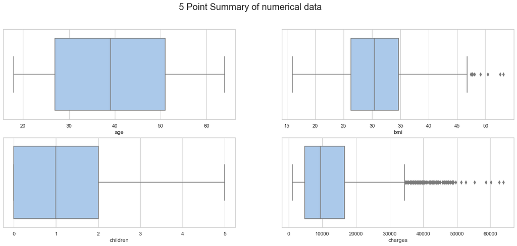

```python
fig, ax = plt.subplots(2,2);
plt.suptitle("5 Point Summary of numerical data", fontsize=20)
sns.boxplot(df['age'],ax=ax[0,0]);
sns.boxplot(df['bmi'],ax=ax[0,1]);
sns.boxplot(df['children'],ax=ax[1,0]);
sns.boxplot(df['charges'],ax=ax[1,1]);
```

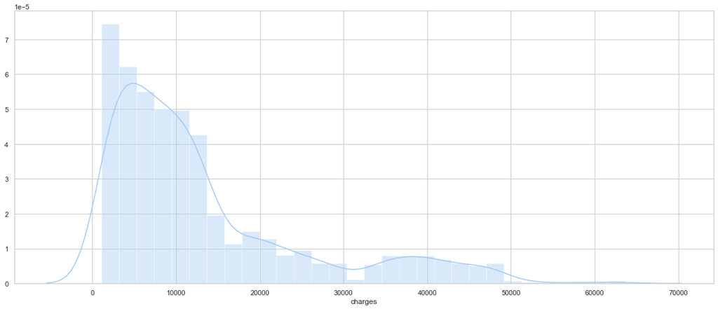

```python
sns.distplot(df.charges);
```

#### (1) Age ranges between 18-64 years with median at 39 which almost same as the average indicating that there are no outliers. Almost 50% of individuals in the dataset are in the age group of 27-51 years i.e in IQR

#### (2) Children ranges between 0-5 with both mean and median around 1 and indicating no outliers. 50% of individuals have <= 2 children.

#### (3) BMI ranges between ~16 to 53 with both mean and median around 30 indicating that there are no significant outliers. Almost 50% of individuals have their BMI between 26 to 34.

#### (4) Charges has a wide range between ~1200 to 63000 USD and has significant outliers in the data. The mean is at 13270 USD and median around 9300USD. This shows that the data is right skewed as shown in the histogram above.

### Add a column to the dataframe to categorise an individual as underweight,Normal weight, Over weight or Obese.

#### Reference : https://www.nhlbi.nih.gov/health/educational/lose_wt/BMI/bmicalc.htm

#### BMI Categories:

#### Underweight = <18.5

#### Normal weight = 18.5–24.9

#### Overweight = 25–29.9

#### Obesity = BMI of 30 or greater

```python
df['weight_type'] = df['bmi'].apply(lambda x: 'underweight'
                if x <= 18.5
                else ('normalweight' if (18.5 <= x <= 24.9)
                      else ('overweight' if(25 <= x <= 29.9)
                            else 'obese')))
df.head(10)
```

|  | age | sex | bmi | children | smoker | region | charges | weight_type |
| --- | --- | --- | --- | --- | --- | --- | --- | --- |
| 0 | 19 | female | 27.900 | 0 | yes | southwest | 16884.92400 | overweight |
| 1 | 18 | male | 33.770 | 1 | no | southeast | 1725.55230 | obese |
| 2 | 28 | male | 33.000 | 3 | no | southeast | 4449.46200 | obese |
| 3 | 33 | male | 22.705 | 0 | no | northwest | 21984.47061 | normalweight |
| 4 | 32 | male | 28.880 | 0 | no | northwest | 3866.85520 | overweight |
| 5 | 31 | female | 25.740 | 0 | no | southeast | 3756.62160 | overweight |
| 6 | 46 | female | 33.440 | 1 | no | southeast | 8240.58960 | obese |
| 7 | 37 | female | 27.740 | 3 | no | northwest | 7281.50560 | overweight |
| 8 | 37 | male | 29.830 | 2 | no | northeast | 6406.41070 | overweight |
| 9 | 60 | female | 25.840 | 0 | no | northwest | 28923.13692 | overweight |

```python
df.groupby(by='weight_type').mean()
```

| weight_type | age | bmi | children | charges |
| --- | --- | --- | --- | --- |
| normalweight | 36.764706 | 22.602670 | 1.117647 | 10404.900084 |
| obese | 40.318498 | 35.156196 | 1.107093 | 15479.549773 |
| overweight | 38.899204 | 27.547228 | 1.061008 | 10993.994037 |
| underweight | 32.380952 | 17.610714 | 1.047619 | 8657.620652 |

```
Average medical charges per weight type :
weight_type
normalweight    10404.900084
obese           15479.549773
overweight      10993.994037
underweight      8657.620652
Name: charges, dtype: float64

Maximum medical charges per weight type :
 weight_type
normalweight    35069.37452
obese           63770.42801
overweight      38245.59327
underweight     32734.18630
Name: charges, dtype: float64
```

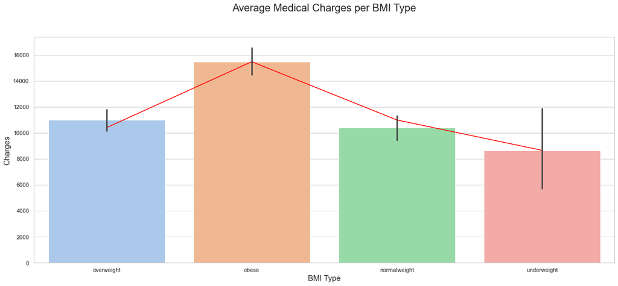

```python
print(f"\nAverage medical charges per weight type : \n{df.groupby(by='weight_type')['charges'].mean()}")
print(f"\nMaximum medical charges per weight type : \n {df.groupby(by='weight_type')['charges'].max()}")


df.groupby(by='weight_type')['charges'].mean().plot(color='red');

sns.barplot(df['weight_type'],df['charges']);
plt.title("Average Medical Charges per BMI Type",fontsize=20,y=1.1);
plt.xlabel('BMI Type',fontsize=15);
plt.ylabel('Charges',fontsize=15);
```

#### Younger people manage their weight better than the older ones. Also, the medical charges depends on the weight_type or BMI category of the individual.

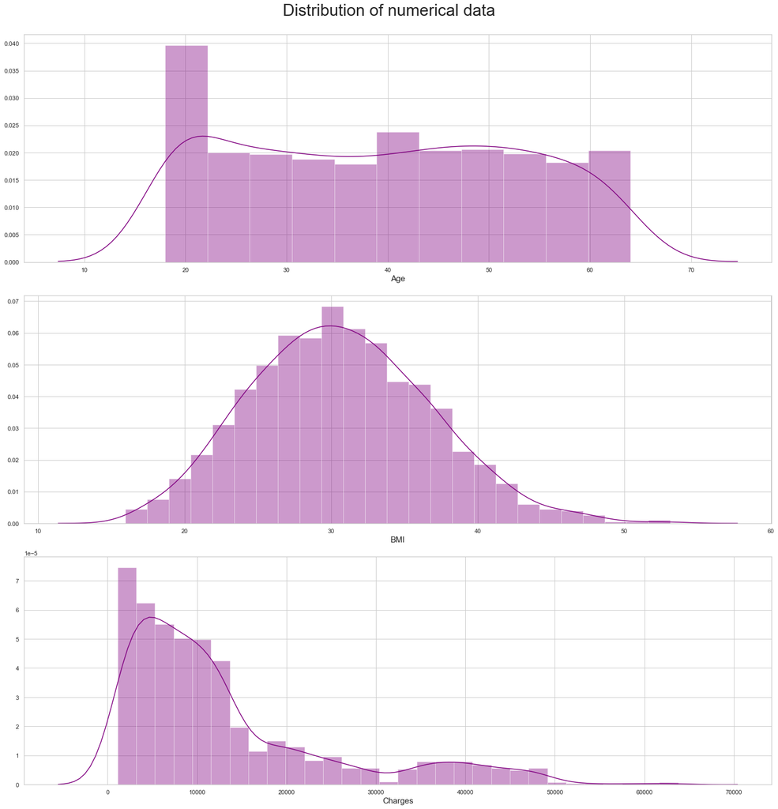

```python
# Distribution og 'bmi','age' and 'charges'
fig, ax = plt.subplots(3,1,figsize=(20,20));
plt.suptitle("Distribution of numerical data",y=1.03, fontsize=30)
# fig.subplots_adjust(top=0.85, wspace=0.3)

sns.distplot(df['age'],ax=ax[0], color='purple');
ax[0].set_xlabel("Age",fontsize=15)

sns.distplot(df['bmi'],ax=ax[1],color='purple');
ax[1].set_xlabel("BMI",fontsize=15)

sns.distplot(df['charges'],ax=ax[2],color='purple');
ax[2].set_xlabel("Charges",fontsize=15)

# sns.distplot(df['children'],ax=ax[1,1]);

plt.tight_layout()

plt.show()
```

#### (1) : The age seems to be uniformly distributed with mean and median at 39 years and no outliers.

#### (2) : The BMI is normalluy distributed without much outliers.

#### (3) : The charges column has a right- skewed distribution with significant outliers.

```python
# Measure of skewness of 'bmi','age' and 'charges'
# print(df.skew())
ins_skew = pd.DataFrame({'Skewness':[df.age.skew(),df.bmi.skew(),df.charges.skew()]},index=['age','bmi','charges'])
ins_skew
```

|  | Skewness |
| --- | --- |
| age | 0.055673 |
| bmi | 0.284047 |
| charges | 1.515880 |

#### (1) Age is uniformly distributed as see above and has little to no skewness.

#### (2) BMI as seen earlier is normally distributed and does not have any skewness visible.

#### (3) Charges are highly skewed to the right.

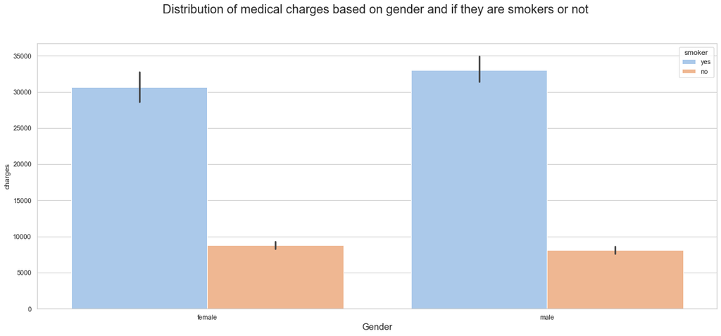

```python
sns.barplot(x='sex',y='charges',data=df,orient='v',hue=df['smoker']).set_title("Distribution of medical charges based on gender and if they are smokers or not ",fontsize=20,y=1.1);
plt.xlabel("Gender",fontsize=15);
```

#### Regardless of the sex, smokers tend to cough out more on medical charges compared to non-smokers.

```python
female_smoke_prem = df[(df['smoker'] == 'yes') & (df['sex'] == 'female')]['charges'].mean()
male_smoke_prem = df[(df['smoker'] == 'yes') & (df['sex'] == 'male')]['charges'].mean()
avg_smoke_prem = df[(df['smoker'] == 'yes')]['charges'].mean()
avg_nonsmoke_prem = df[(df['smoker'] == 'no')]['charges'].mean()

print(f"\nSmokers on an average pay ${avg_smoke_prem:.2f} of medical charges which on an average is {round(avg_smoke_prem/avg_nonsmoke_prem)} times more than non-smokers who pay an average of ${avg_nonsmoke_prem:.2f}  )" )
# female_smoke_prem,male_smoke_prem,avg_smoke_prem,avg_nonsmoke_prem
```

```
Smokers on an average pay $32050.23 of medical charges which on an average is 4 times more than non-smokers who pay an average of $8434.27  )
```

### Prior to pair plotting we will label encode the categorical variables to see if there is a visible correlation among other variables.

```python
df1 = df.copy()
df1.head()
```

|  | age | sex | bmi | children | smoker | region | charges | weight_type |
| --- | --- | --- | --- | --- | --- | --- | --- | --- |
| 0 | 19 | female | 27.900 | 0 | yes | southwest | 16884.92400 | overweight |
| 1 | 18 | male | 33.770 | 1 | no | southeast | 1725.55230 | obese |
| 2 | 28 | male | 33.000 | 3 | no | southeast | 4449.46200 | obese |
| 3 | 33 | male | 22.705 | 0 | no | northwest | 21984.47061 | normalweight |
| 4 | 32 | male | 28.880 | 0 | no | northwest | 3866.85520 | overweight |

```python
from sklearn.preprocessing import LabelEncoder

df1[['sex','smoker','region','weight_type']] = df1[['sex','smoker','region','weight_type']].apply(LabelEncoder().fit_transform)
df1.head(10)
```

|  | age | sex | bmi | children | smoker | region | charges | weight_type |
| --- | --- | --- | --- | --- | --- | --- | --- | --- |
| 0 | 19 | 0 | 27.900 | 0 | 1 | 3 | 16884.92400 | 2 |
| 1 | 18 | 1 | 33.770 | 1 | 0 | 2 | 1725.55230 | 1 |
| 2 | 28 | 1 | 33.000 | 3 | 0 | 2 | 4449.46200 | 1 |
| 3 | 33 | 1 | 22.705 | 0 | 0 | 1 | 21984.47061 | 0 |
| 4 | 32 | 1 | 28.880 | 0 | 0 | 1 | 3866.85520 | 2 |
| 5 | 31 | 0 | 25.740 | 0 | 0 | 2 | 3756.62160 | 2 |
| 6 | 46 | 0 | 33.440 | 1 | 0 | 2 | 8240.58960 | 1 |
| 7 | 37 | 0 | 27.740 | 3 | 0 | 1 | 7281.50560 | 2 |
| 8 | 37 | 1 | 29.830 | 2 | 0 | 0 | 6406.41070 | 2 |
| 9 | 60 | 0 | 25.840 | 0 | 0 | 1 | 28923.13692 | 2 |

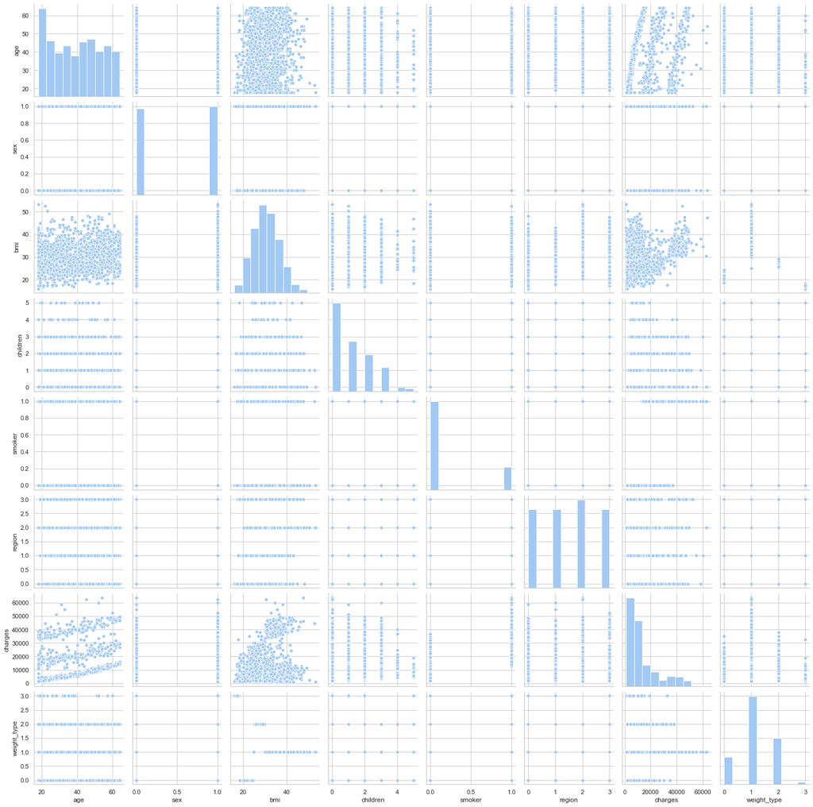

```python
sns.pairplot(df1,palette='hls');
```

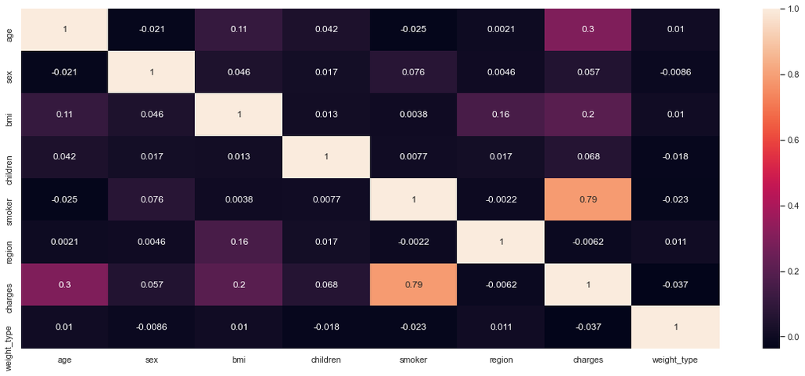

```python
sns.heatmap(df1.corr(),annot=True);
```

#### From both pairplot and heatmap we can see that there is a higher correlation between charges and smoking i.e Smokers tend to bill more.

#### Followed by age and charges i.e people in the higher age group bill higher medical expenses

#### The same is true for people with higher bmi i.e the more obese people bill more medical expenses.

#### In summary, the medical charges are proportional to lifestyle, habbits and age. However, there is no significant correlation between charges and the number of children

```python
# plt.figure(figsize = (20,15))
# fig, ax = plt.subplots(2,1,sharex=True)
# sns.scatterplot(x = "age", y = "charges", data = df, hue = "sex",ax=ax[0]).set_title("Distribution of charges by age and sex",fontsize=15);
# sns.scatterplot(x = "age", y = "bmi", data = df, hue = "sex",ax=ax[1]).set_title("Distribution of BMI by age and sex",fontsize=15);
```

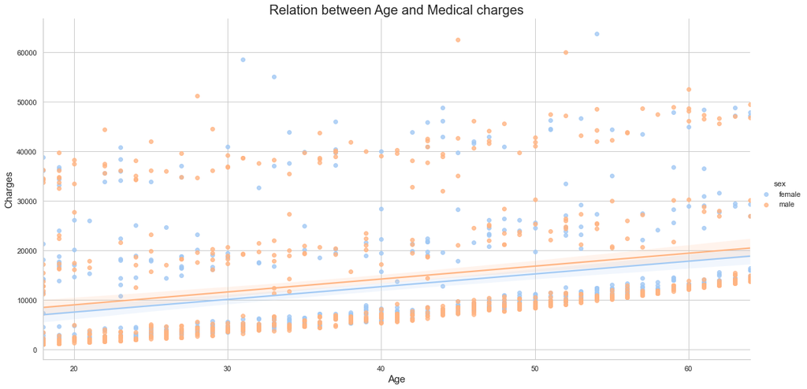

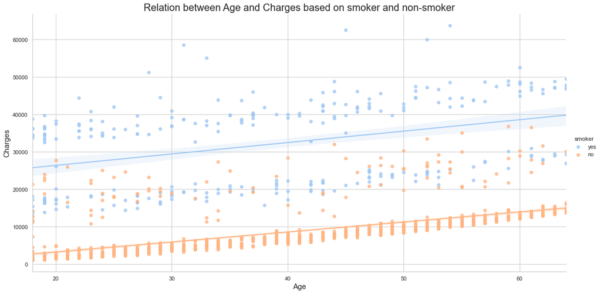

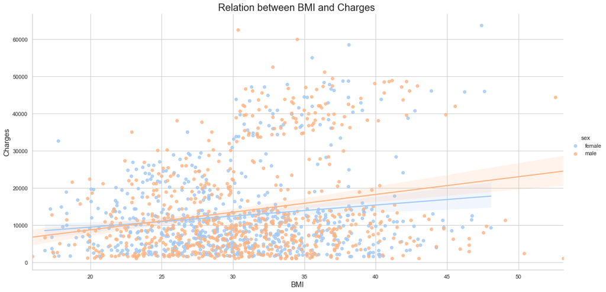

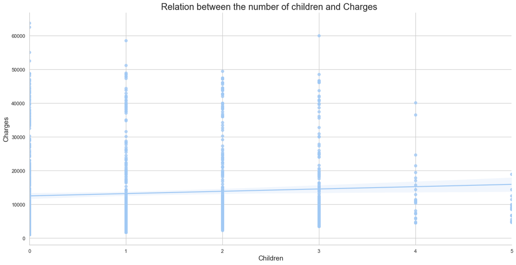

```python
# fig, ax = plt.subplots();
sns.lmplot(x = "age", y = "charges", data = df, hue = "sex",height=8,aspect=2,sharex=True);
plt.title('Relation between Age and Medical charges',fontsize=20)
plt.xlabel('Age',fontsize=15);
plt.ylabel('Charges',fontsize=15);

sns.lmplot(x = "age", y = "charges", data = df, hue = "smoker",height=8,aspect=2,sharex=True);
plt.title('Relation between Age and Charges based on smoker and non-smoker',fontsize=20)
plt.xlabel('Age',fontsize=15);
plt.ylabel('Charges',fontsize=15);

sns.lmplot(x = "bmi", y = "charges", data = df, hue = "sex",height=8,aspect=2,sharex=True);
plt.title('Relation between BMI and Charges ',fontsize=20)
plt.xlabel('BMI',fontsize=15);
plt.ylabel('Charges',fontsize=15);

sns.lmplot(x = "children", y = "charges", data = df, height=8,aspect=2,sharex=True);
plt.title('Relation between the number of children and Charges ',fontsize=20)
plt.xlabel('Children',fontsize=15);
plt.ylabel('Charges',fontsize=15);

plt.show()
```

```python
# #  fig, ax = plt.subplots(sharex=True);
# fig, ax = plt.subplots(3,1,sharex=True);
# sns.lineplot(x = "age", y = "charges", data = df, hue = "sex",ax=ax[0]);
# sns.lineplot(x = "age", y = "bmi", data = df, hue = "sex",ax=ax[1]);
# sns.lineplot(x = "age", y = "charges", data = df, hue = "smoker",ax=ax[2]);
```

### Other distributions

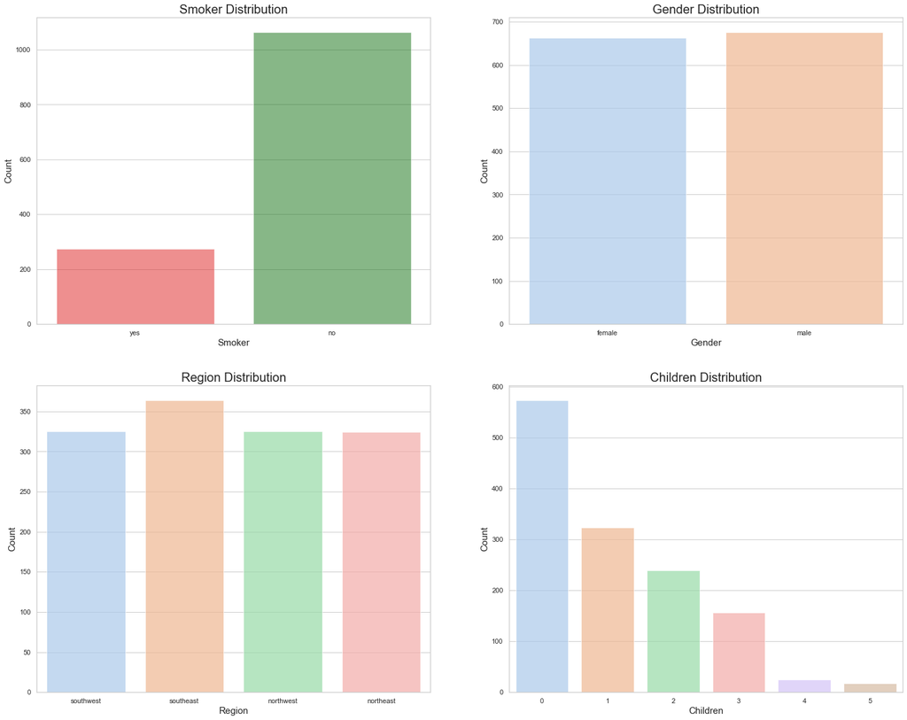

```python
# fig, ax = plt.subplots(sharex=True);
fig, ax = plt.subplots(2,2,figsize=(25,20));
# ax00 = sns.countplot(x="smoker",data=df,ax=ax[0,0],palette=["red","green"],alpha=0.5).set_title("Smoker Distribution",fontsize=20);
ax00 = sns.countplot(x="smoker",data=df,ax=ax[0,0],palette=["red","green"],alpha=0.5);
ax00.set_title("Smoker Distribution",fontsize=20);
ax00.set_xlabel("Smoker",fontsize=15);
ax00.set_ylabel("Count",fontsize=15);

ax01 = sns.countplot(x="sex",data=df,ax=ax[0,1],alpha=0.7);
ax01.set_title("Gender Distribution",fontsize=20);
ax01.set_xlabel("Gender",fontsize=15);
ax01.set_ylabel("Count",fontsize=15);

ax10 = sns.countplot(x="region",data=df,ax=ax[1,0],alpha=0.7);
ax10.set_title("Region Distribution",fontsize=20);
ax10.set_xlabel("Region",fontsize=15);
ax10.set_ylabel("Count",fontsize=15);

ax11 = sns.countplot(x="children",data=df,ax=ax[1,1],alpha=0.7);
ax11.set_title("Children Distribution",fontsize=20);
ax11.set_xlabel("Children",fontsize=15);
ax11.set_ylabel("Count",fontsize=15);
```

#### As shown in the count plots:

#### (1) The sample contains more non-smokers than smokers.

#### (2) The sample conatins almost equal proportions of male and females.

#### (3) The samle conatins a fairly equal share from all 4 regions.

#### (4) There are significant number of people in the sample with less than 2 children

## (4) Hypothesis testing

### (4.1) Do charges of people who smoke differ significantly from the people who don't?

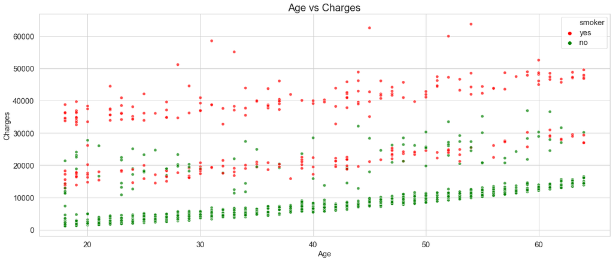

```python
ax1 = sns.scatterplot(df['age'],df['charges'],hue=df['smoker'],palette=["red","green"],alpha=0.7);
ax1.set_title("Age vs Charges",fontsize=20);
ax1.set_xlabel("Age",fontsize=15);
ax1.set_ylabel("Charges",fontsize=15);
plt.setp(ax1.get_legend().get_texts(), fontsize='15');
plt.setp(ax1.get_xticklabels(), fontsize=15);
plt.setp(ax1.get_yticklabels(), fontsize=15);
```

#### Visual representation shows that smokers pay more than non-smokers for the same age.

#### To prove with the statistical evidence,

#### (*) Null Hypothesis or H0 : There is no difference between smoker and non-smoker for the medical charges.

#### (*) Alternate Hypothesis or Ha : Charges are not the same.

#### (*) $\alpha$ or level of significance = 5% or 0.05

```python
len(df[df["smoker"]=="yes"]["charges"]) , len(df[df["smoker"]=="no"]["charges"])
```

```
(274, 1064)
```

#### Since the sample size is well above 30 we will use "Two-Sample Z Test" to check if the sample mean are same or not at a significance level of 0.05

```python
p_alpha = 0.05
h0 = "there is no difference between smoker and non-smoker for the medical charges."
h1 = "there is a difference between smoker and non-smoker for the medical charges"
```

```python
# Method-1 using Z Test
z_stat,z_p_value= ztest(df[df["smoker"]=="yes"]["charges"], df[df["smoker"]=="no"]["charges"])
print(z_stat,z_p_value)

if z_p_value < p_alpha :
    print(f"Reject the Null Hypothesis H0 as p_value {z_p_value:.4} is less than {p_alpha:.4}.\nHence,{h1}")
else:
    print(f"Failing to reject the Null Hypothesis H0 as p_value {z_p_value:.4} is greater than {p_alpha:.4}.\nHence,{h0} ")
```

```
46.664921172723716 0.0
Reject the Null Hypothesis H0 as p_value 0.0 is less than 0.05.
Hence,there is a difference between smoker and non-smoker for the medical charges
```

```python
# Method 2 using T-Test of independent variable
t_stat,t_p_value= stats.ttest_ind(df[df["smoker"]=="yes"]["charges"], df[df["smoker"]=="no"]["charges"],axis=0 )
print(t_stat,t_p_value)

if t_p_value < p_alpha :
    print(f"Reject the Null Hypothesis H0 as p_value {t_p_value:.4} is less than {p_alpha:.4}.\nHence,{h1}")
else:
    print(f"Failing to reject the Null Hypothesis H0 as p_value {t_p_value:.4} is greater than {p_alpha:.4}.\nHence,{h0} ")
```

```
46.664921172723716 8.271435842177219e-283
Reject the Null Hypothesis H0 as p_value 8.271e-283 is less than 0.05.
Hence,there is a difference between smoker and non-smoker for the medical charges
```

### Hence it can be confirmed through a statistical evidence that charges vary significantly between smokers and non-smokers.

#### Both t and z test confirms the alternate hypothesis.

### (4.2) Does BMI of males differ significantly from that of females?

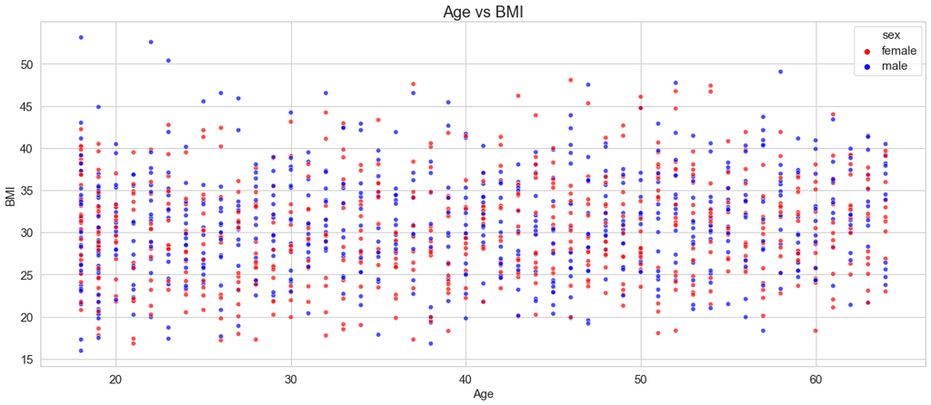

```python
ax1 = sns.scatterplot(df['age'],df['bmi'],hue=df['sex'],palette=["red","blue"],alpha=0.7);
ax1.set_title("Age vs BMI",fontsize=20);
ax1.set_xlabel("Age",fontsize=15);
ax1.set_ylabel("BMI",fontsize=15);
plt.setp(ax1.get_legend().get_texts(), fontsize='15');
plt.setp(ax1.get_xticklabels(), fontsize=15);
plt.setp(ax1.get_yticklabels(), fontsize=15);
```

### Visulaly there is no apparent relation between the BMI and gender.

#### To prove with the statistical evidence,

#### (*) Null Hypothesis or H0 : Gender has no effect on the BMI i.e BMI of male and female are same.

#### (*) Alternate Hypothesis or Ha : Gender has an effect on the BMI i.e BMI of male and female are different.

#### (*) 𝛼 or level of significance = 5% or 0.05

```python
len(df[df["sex"]=="male"]["bmi"]) , len(df[df["sex"]=="female"]["bmi"])
```

```
(676, 662)
```

```python
p_alpha = 0.05
h0 = "there is no effect of gender on the BMI."
h1 = "there is an effect of gender on the BMI."
```

```python
# method 1, using Z test
z_stat,z_p_value= ztest(df[df["sex"]=="male"]["bmi"], df[df["sex"]=="female"]["bmi"])
print(z_stat,z_p_value)

if z_p_value < p_alpha :
    print(f"Reject the Null Hypothesis H0 as p_value {z_p_value:.4} is less than {p_alpha:.4}.\nHence,{h1}")
else:
    print(f"Failing to reject the Null Hypothesis H0 as p_value {z_p_value:.4} is greater than {p_alpha:.4}.\nHence,{h0} ")
```

```
1.6967526357522242 0.08974343679943912
Failing to reject the Null Hypothesis H0 as p_value 0.08974 is greater than 0.05.
Hence,there is no effect of gender on the BMI.
```

```python
# Method 2, using t-Test of independent variable

t_stat,t_p_value= stats.ttest_ind(df[df["sex"]=="male"]["bmi"], df[df["sex"]=="female"]["bmi"],axis=0 )
print(t_stat,t_p_value)

if t_p_value < p_alpha :
    print(f"Reject the Null Hypothesis H0 as p_value {t_p_value:.4} is less than {p_alpha:.4}.\nHence,{h1}")
else:
    print(f"Failing to reject the Null Hypothesis H0 as p_value {t_p_value:.4} is greater than {p_alpha:.4}.\nHence,{h0} ")
```

```
1.696752635752224 0.08997637178984932
Failing to reject the Null Hypothesis H0 as p_value 0.08998 is greater than 0.05.
Hence,there is no effect of gender on the BMI.
```

#### Both z and t test provide similar results with p_value which fails to reject the null hypothesis H0.

### (4.3) Is the proportion of smokers significantly different in different genders?

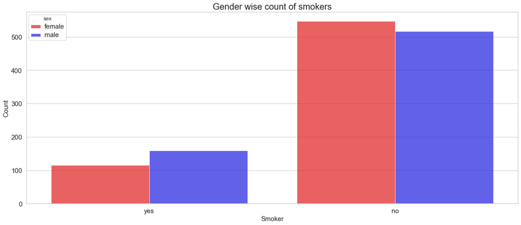

```python
ax1 = sns.countplot(df['smoker'],hue=df['sex'],palette=["red","blue"],alpha=0.7);
ax1.set_title("Gender wise count of smokers",fontsize=20);
ax1.set_xlabel("Smoker",fontsize=15);
ax1.set_ylabel("Count",fontsize=15);
plt.setp(ax1.get_legend().get_texts(), fontsize='15');
plt.setp(ax1.get_xticklabels(), fontsize=15);
plt.setp(ax1.get_yticklabels(), fontsize=15);
```

#### Visual comparison shows that the gender has an effect on the smoking habits.

#### To prove with the statistical evidence,

#### (*) Null Hypothesis or H0 : Gender has no effect on the smoking habits.

#### (*) Alternate Hypothesis or Ha : Gender has an effect on the smoking habits.

#### (*) 𝛼 or level of significance = 5% or 0.05

#### (*) We will use Chi-Square test the statistical significance as these are catogorical variables.

#### (*) We will use chi2_contingency API as we are testing the relationship between the categorical variables "smoker" and "sex".

```python
# Creating the contingency table
cont_table = pd.crosstab(df['sex'],df['smoker'])
cont_table
```

| smoker sex | no | yes |
| --- | --- | --- |
| female | 547 | 115 |
| male | 517 | 159 |

```python
p_alpha = 0.05
h0 = "there is no effect of gender on the smoking habits."
h1 = "there is an effect of gender on the smoking habits."
```

```python
chi2_stats, chi2_p, dof, expect = stats.chi2_contingency(cont_table)

# chi2_stats, chi2_p, dof, _

print(f"(1) Chi2 Statistic : {chi2_stats:.4}\n(2) p_value : {chi2_p:.4}\n(3) Degree of Freedom : {dof}")

if chi2_p < p_alpha :
    print(f"\nReject the Null Hypothesis H0 as p_value {chi2_p:.4} is less than {p_alpha:.4}.\nHence,{h1}")
else:
    print(f"\nFailing to reject the Null Hypothesis H0 as p_value {chi2_P:.4} is greater than {p_alpha:.4}.\nHence,{h0} ")
```

```
(1) Chi2 Statistic : 7.393
(2) p_value : 0.006548
(3) Degree of Freedom : 1

Reject the Null Hypothesis H0 as p_value 0.006548 is less than 0.05.
Hence,there is an effect of gender on the smoking habits.
```

### (4.4) Is the distribution of bmi across women with no children, one child and two children, the same?

```python
# df[df['sex'] == 'female']['children'].count() , df[df['sex'] == 'female']['bmi'].count()
```

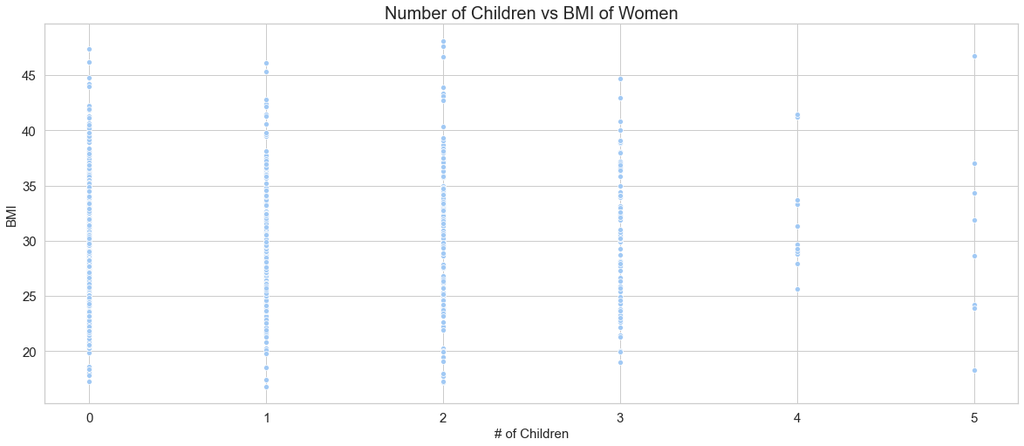

```python
ax1 = sns.scatterplot(df[df['sex'] == 'female']['children'],df[df['sex'] == 'female']['bmi']);
ax1.set_title("Number of Children vs BMI of Women",fontsize=20);
ax1.set_xlabel("# of Children",fontsize=15);
ax1.set_ylabel("BMI",fontsize=15);
# plt.setp(ax1.get_legend().get_texts(), fontsize='15');
plt.setp(ax1.get_xticklabels(), fontsize=15);
plt.setp(ax1.get_yticklabels(), fontsize=15);
```

#### There does not seem to be apparent effect of number of children on the BMI.

#### To prove with the statistical evidence,

#### (*) Null Hypothesis or H0 : The number of children has no effect on the BMI of women i.e means across sample are not different.

#### (*) Alternate Hypothesis or Ha : The number of children has an effect on the BMI of women. i.e means across samples are different.

#### (*) 𝛼 or level of significance = 5% or 0.05

```python
# Create groups of women based on the number of children

no_child = df[(df['sex'] == 'female') & (df['children'] == 0)]['bmi']
one_child = df[(df['sex'] == 'female') & (df['children'] == 1)]['bmi']
two_child = df[(df['sex'] == 'female') & (df['children'] == 2)]['bmi']

# print the Sample size, mean and standard deviations for the samples.
print(f" (1) Sample Size for No child, One Child and Two child :{no_child.count(),one_child.count(),two_child.count()}")
print(f" (2) Mean  for No child, One Child and Two child :{no_child.mean(),one_child.mean(),two_child.mean()}")
print(f" (3) Standard Devation for No child, One Child and Two child :{no_child.std(),one_child.std(),two_child.std()}")
```

```
 (1) Sample Size for No child, One Child and Two child :(289, 158, 119)
 (2) Mean  for No child, One Child and Two child :(30.36152249134948, 30.0526582278481, 30.64978991596638)
 (3) Standard Devation for No child, One Child and Two child :(5.966934229366255, 5.786831048981313, 6.628199943377461)
```

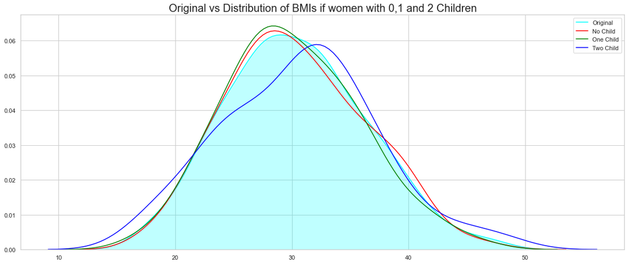

```python
#Visual test for normality
# fig = plt.figure()
sns.kdeplot(df[(df['sex'] == 'female')]['bmi'],color="cyan",label = 'Original',shade=True);
sns.kdeplot(no_child,color="red",label = 'No Child');
sns.kdeplot(one_child,color="green",label = 'One Child');
sns.kdeplot(two_child,color="blue",label = 'Two Child');
plt.title("Original vs Distribution of BMIs if women with 0,1 and 2 Children", fontsize=20);
```

#### From the above output we coud see that the means for all samples and their standard deviations are almost similar. Hence, there is a chance that we fail to reject the Null Hypotheis .

#### Visual test shows that both population and samples are normally distributed.

```python
p_alpha = 0.05
h0 = "the number of children has no effect on the BMI of women i.e means across sample are not different."
h1 = "the number of children has an effect on the BMI of women. i.e means across samples are different."
```

```python
#  Method 1: Testing with F statistic
f_stat,f_p_value = stats.f_oneway(no_child,one_child,two_child,axis=0)

f_stat,f_p_value

print(f"(1) F Statistic : {f_stat:.4}\n(2) p_value : {f_p_value:.4}")

if f_p_value < p_alpha :
    print(f"\nReject the Null Hypothesis H0 as p_value {f_p_value:.4} is less than {p_alpha:.4}.\nHence,{h1}")
else:
    print(f"\nFailing to reject the Null Hypothesis H0 as p_value {f_p_value:.4} is greater than {p_alpha:.4}.\nHence,{h0} ")
```

```
(1) F Statistic : 0.3345
(2) p_value : 0.7159

Failing to reject the Null Hypothesis H0 as p_value 0.7159 is greater than 0.05.
Hence,the number of children has no effect on the BMI of women i.e means across sample are not different.
```

```python
# Method 1: Testing with F statistic using Statsmodel API.

# Create a new dataframe for women with children <= 2.
df_bmi = df[(df['children'] <= 2) & (df['sex'] == 'female')].copy()
df_bmi['children'] = df_bmi['children'].astype('category')
df_bmi.head()
```

|  | age | sex | bmi | children | smoker | region | charges | weight_type |
| --- | --- | --- | --- | --- | --- | --- | --- | --- |
| 0 | 19 | female | 27.90 | 0 | yes | southwest | 16884.92400 | overweight |
| 5 | 31 | female | 25.74 | 0 | no | southeast | 3756.62160 | overweight |
| 6 | 46 | female | 33.44 | 1 | no | southeast | 8240.58960 | obese |
| 9 | 60 | female | 25.84 | 0 | no | northwest | 28923.13692 | overweight |
| 11 | 62 | female | 26.29 | 0 | yes | southeast | 27808.72510 | overweight |

```python
# model = ols('charges ~ C(region) + C(smoker) + age + C(sex) + children',data=df).fit()
model = ols('bmi ~ C(children)',data=df_bmi).fit()
anova_result = sm.stats.anova_lm(model,typ=1)

print(anova_result)

a_p_value = anova_result.loc['C(children)','PR(>F)']

if a_p_value < p_alpha :
    print(f"\nReject the Null Hypothesis H0 as p_value {a_p_value:.4} is less than {p_alpha:.4}.\nHence,{h1}")
else:
    print(f"\nFailing to reject the Null Hypothesis H0 as p_value {a_p_value:.4} is greater than {p_alpha:.4}.\nHence,{h0} ")
```

```
                df        sum_sq    mean_sq         F    PR(>F)
C(children)    2.0     24.590123  12.295062  0.334472  0.715858
Residual     563.0  20695.661583  36.759612       NaN       NaN

Failing to reject the Null Hypothesis H0 as p_value 0.7159 is greater than 0.05.
Hence,the number of children has no effect on the BMI of women i.e means across sample are not different.
```

#### Statsmodel API also provides the same result as the ANOVA One-way Test.

```python
# # Shapiro-Wilk Normality Test. Ho : The population is normally distributed. H1: The population is not normally distributed.

# print(stats.shapiro(no_child),stats.shapiro(one_child),stats.shapiro(two_child))
# # Box-Cox Transformation of Data
# no_fit_data, _ = stats.boxcox(no_child)
# one_fit_data, _ = stats.boxcox(one_child)
# two_fit_data, _ = stats.boxcox(two_child)
# print("\n ------- After Box-Cox transformation ------ \n ")
# print(stats.shapiro(no_fit_data),stats.shapiro(one_fit_data),stats.shapiro(two_fit_data) )

# sns.kdeplot(df[(df['sex'] == 'female')]['bmi'],color="purple");
# sns.kdeplot(no_child,color="red");
# sns.kdeplot(one_child,color="green");
# sns.kdeplot(two_child,color="blue");
```

```python
# Levene Test for variance
# stats.levene(no_fit_data,one_fit_data,two_fit_data)
```

```python
# f_stat,f_p_value = stats.f_oneway(no_fit_data,one_fit_data,two_fit_data,axis=0)

# f_stat,f_p_value
```

```python
# import statsmodels.api as sm
# import pylab as py
```

```python
# sm.qqplot(no_child,line='q');
# sm.qqplot(no_fit_data,line='q');
# # sm.qqplot(two_child,line='q');
```

```python
# stats.mannwhitneyu(no_child,one_child), stats.mannwhitneyu(one_child,two_child), stats.mannwhitneyu(two_child,no_child)
```